# IND320 Project P2

Author: Robin Torjussen Egede  
[Streamlit P2 page](https://ind320-hush-p2.streamlit.app) - [P1 page](https://ind320-hush.streamlit.app)  
[Repo & P2 branch](https://github.com/Kunii/IND320-hush/tree/work-p2)

(Streamlit does not support changing branch for the online served page, hence the split)

[video not shown]

( Video ran long - Use the speedup feature :) )

## Log

Before changing anything I:

- Made a snapshot branch of P1.
- Reorganised the loose files into the `CA1` folder.
- Created a separate `work-p2` branch so that peer-review changes do not clutter `main`.
- Set up a new online streamlit app linked to the new branch.

Did the local cassandra + spark setup. The notebook starts the container automatically if it is stopped.  
Spark caused the most friction: the original Python 3.14/JDK combination did not work.  
I changed to Python 3.12, installed OpenJDK 17 and explicitly set `JAVA_HOME` before importing PySpark.

MongoDB:  
The connection string and ENTSO-E token are read through `SecretManager` (created in P1).  
No credentials are stored in the notebook or on git.

API data: API results are cached as local parquet files under `data/cache`.  
Rerunning the notebook does not re-query the api.  
Bool flags `REFRESH_NVE` and `REFRESH_ENTSOE` force a fresh fetch if needed.

NVE:  
The NVE Magasinstatistikk data are now fetched directly from `HentOffentligData`.  
Otherwise more or less the same as P1.

ENTSOE:  
Chose `documentType` = `A11`, as this was listed as `Cross-Border Physical Flows`.  
Fetched `Area Y` EIC codes from `https://www.entsoe.eu/data/energy-identification-codes-eic/eic-approved-codes` (`data/Y_eicCodes.csv`).  
Chose code `10YNO-0--------C` for Norway. Visually inspected the web-gui for connected countries.  
Concluded the neighbours are: SE, FI, NL, GB, DK, DE.

Every neighbouring country is queried in both directions (due to values being positive only):

- `NO -> neighbour` for exports
- `neighbour -> NO` for imports.

The `A11` responses contain mixed time resolutions.  
The parser stores the resolution and converts each observation to hours before converting to Wh.  
The rows are written to Cassandra with Spark, read back through Spark SQL.

Finally, rows are inserted into MongoDB in chunks.

Streamlit:  
Removed the dummy page and reorganised the app into:

- Home
- Reservoir table
- Reservoir plot
- Cross-border flows

The reservoir pages share a cached NVE loader,  
and the session-state interval controlled by the slider on the plot page.  
Radio buttons for EL, NO or VASS.  
The cross-border page uses two columns with radios for desired connection and year selector on the left.  
Pill buttons for month and a line plot on the right.  
Expander below for the required brief data source doc.

I figured I would give AI driven dev a shot.  
Therefor I prototyped all of the above (except for the new streamlit stuff),  
and let the agent finish the work. Lastly I did the final polish myself before delivery.

## AI usage

Used as "fancy auto-complete" in-line suggestions, docstring & in-line comment drafts, plotting drafts.  
All logic is my own.  
I let a fully autonomous agent take my "80%"-prototype to "fully developed".

```python
import os
import time

# TZ=UTC is set before pandas/PySpark are imported
# Keeps the Python, Spark and Cassandra interpretations of timestamps identical
os.environ["TZ"] = "UTC"
os.environ["JAVA_HOME"] = "/usr/lib/jvm/java-17-openjdk-amd64"
if hasattr(time, "tzset"):
    time.tzset()

from dataclasses import dataclass
from pathlib import Path
from typing import Any
from xml.etree import ElementTree as ET

import matplotlib.pyplot as plt
import pandas as pd
import requests
from cassandra.cluster import Cluster
from docker import from_env
from IPython.display import display
from pymongo import MongoClient
from pyspark.sql import SparkSession

from src.utils.env import secrets
from src.utils.magasin import (
    MEASUREMENT_COLUMNS,
    PARQUET_CACHE,
    REQUIRED_COLUMNS,
    fetch_magasinstatistikk,
)

# Make wide tables readable and use a clean matplotlib theme.
pd.set_option("display.max_columns", 50)
plt.style.use("seaborn-v0_8-whitegrid")

# Locate the repository root by walking upwards until pyproject.toml is found.
# This keeps paths valid whether the notebook is run from notebooks/CA2 or
# from the repository root.
REPO_ROOT = next(
    p for p in [Path.cwd(), *Path.cwd().parents] if (p / "pyproject.toml").exists()
)

# Downloaded API data are cached here as parquet files. The notebook reads
# from these files when they exist, so a normal re-run makes no HTTP calls.
CACHE_DIR = REPO_ROOT / "data" / "cache"
CACHE_DIR.mkdir(parents=True, exist_ok=True)

MWH_PER_TWH = 1000000

def require_columns(
    frame: pd.DataFrame,
    required: tuple[str, ...] | list[str],
    source: str,
) -> None:
    """Raise a readable error when a cache or API table is incomplete."""
    missing = sorted(set(required) - set(frame.columns))
    if missing:
        raise ValueError(f"{source} is missing columns: {', '.join(missing)}")
```

```
2026-10-20 21:21:57.038 No runtime found, using MemoryCacheStorageManager
2026-10-20 21:21:57.039 No runtime found, using MemoryCacheStorageManager
```

```
No secrets path provided
Defaulting to: [REDACTED]/IND320-hush/.secrets/secrets.toml
```

```python
# Credentials are kept in .secrets/secrets.toml locally and in Streamlit's
# secret store when deployed. The MongoDB URL contains placeholders that are
# replaced at runtime so the real password never appears in the notebook.
mongo_username = secrets.get_required("mongo_db.username")
mongo_password = secrets.get_required("mongo_db.password")
mongo_url = (
    secrets.get_required("mongo_db.url")
    .replace("<username>", mongo_username)
    .replace("<password>", mongo_password)
)

entsoe_token = secrets.get_required("entsoe.token")
```

```python
# The container is given a fixed name so the notebook can find it again after a restart.
# Only the published port (9042) is used by the Python driver and by Spark.
docker_client = from_env()
container = docker_client.containers.get("ind320-cassandra")

if container.status != "running":
    container.start()
    print("Cassandra container started.")
else:
    print(f"Cassandra container already running (status: {container.status}).")

print(container.logs(tail=3).decode("utf-8"))
```

```
Cassandra container already running (status: running).
INFO  [NonPeriodicTasks:1] 2026-10-20T21:11:16,926 BigFormat.java:231 - Deleting sstable: /opt/cassandra/data/data/system/size_estimates-618f817b005f3678b8a453f3930b8e86/nb-130-big
INFO  [NonPeriodicTasks:1] 2026-10-20T21:11:16,926 BigFormat.java:231 - Deleting sstable: /opt/cassandra/data/data/system/size_estimates-618f817b005f3678b8a453f3930b8e86/nb-127-big
INFO  [NonPeriodicTasks:1] 2026-10-20T21:11:16,926 BigFormat.java:231 - Deleting sstable: /opt/cassandra/data/data/system/size_estimates-618f817b005f3678b8a453f3930b8e86/nb-128-big
```

```python
# The Cassandra connector is supplied as a Maven package.
# The connector version must match the Spark/Scala version (Spark 3.5.x, Scala 2.12).
spark = (
    SparkSession.builder.appName("IND320-P2")
    .config(
        "spark.jars.packages",
        "com.datastax.spark:spark-cassandra-connector_2.12:3.5.1",
    )
    .config("spark.cassandra.connection.host", "127.0.0.1")
    .config("spark.cassandra.connection.port", "9042")
    .config("spark.sql.session.timeZone", "UTC")
    .config("spark.ui.enabled", "false")
    .config("spark.driver.memory", "2g")
    .getOrCreate()
)

# Keep the notebook output focused on results rather than Spark WARN lines.
spark.sparkContext.setLogLevel("ERROR")
print(f"Spark version: {spark.version}")
```

[output not shown]

```
:: loading settings :: url = jar:file:/mnt/nvme_storage/projects/NMBU/IND320-hush/.venv/lib/python3.12/site-packages/pyspark/jars/ivy-2.5.1.jar!/org/apache/ivy/core/settings/ivysettings.xml
```

[output not shown]

```
Spark version: 3.5.1
```

```python
# Cassandra connection and Spark-Cassandra round-trip test
KEYSPACE = "ind320"
TEST_TABLE = "connection_test"

cluster = Cluster(["localhost"], port=9042)
session = cluster.connect()
session.execute(
    f"""
    CREATE KEYSPACE IF NOT EXISTS {KEYSPACE}
    WITH REPLICATION = {{'class': 'SimpleStrategy', 'replication_factor': 1}}
    """
)
session.set_keyspace(KEYSPACE)

# Build a tiny table, cassandra, and read it back with Spark.
# This is "proof" that both access paths work before the real data is loaded.
session.execute(f"DROP TABLE IF EXISTS {TEST_TABLE}")
session.execute(
    f"""
    CREATE TABLE {TEST_TABLE} (
        id TIMEUUID PRIMARY KEY,
        name TEXT,
        value DOUBLE,
        created_at TIMESTAMP
    )
    """
)

# Insert
for name, value in [("a", 1.2), ("b", 3.4), ("c", 5.6)]:
    session.execute(
        f"INSERT INTO {TEST_TABLE} (id, name, value, created_at) "
        f"VALUES (now(), '{name}', {value}, currentTimestamp())"
    )

print(f"Cassandra release: {session.execute('SELECT release_version FROM system.local').one().release_version}")
print("Rows written with CQL:")
for row in session.execute(f"SELECT name, value FROM {TEST_TABLE}"):
    print(f"  {row.name}: {row.value}")

# Spark readback
test_sdf = (
    spark.read.format("org.apache.spark.sql.cassandra")
    .options(table=TEST_TABLE, keyspace=KEYSPACE)
    .load()
)
print("Same table read back through Spark:")
test_sdf.show(truncate=False)

# The test table is not needed for the project data.
session.execute(f"DROP TABLE {TEST_TABLE}")
```

```
Cassandra release: 5.0.9
Rows written with CQL:
  a: 1.2
  c: 5.6
  b: 3.4
Same table read back through Spark:
+------------------------------------+-----------------------+----+-----+
|id                                  |created_at             |name|value|
+------------------------------------+-----------------------+----+-----+
|49479a20-cccc-11f1-8ee4-ed9664de04bf|2026-10-20 21:22:00.002|c   |5.6  |
|49477310-cccc-11f1-8ee4-ed9664de04bf|2026-10-20 21:22:00.001|b   |3.4  |
|494724f0-cccc-11f1-8ee4-ed9664de04bf|2026-10-20 21:21:59.999|a   |1.2  |
+------------------------------------+-----------------------+----+-----+
```

```
<cassandra.cluster.ResultSet at 0x7d7589a713d0>
```

## NVE Magasinstatistikk API

P1 read a local `reservoirs.csv`.  
The same public endpoint is now called directly.  
`omrType` contains the three area types (`EL`, `NO`, `VASS`) and `omrnr` is the area number (0-5).  
The keys are renamed to the English names used in P1 so that the plotting code remains comparable.

The cleaned response is cached as `data/cache/magasinstatistikk.parquet`.  
Later runs load that file instead of calling the API.  
Set `REFRESH_NVE = True` to force a new download.

```python
# The NVE rename/type logic lives in src/utils/magasin.py so the notebook and
# the Streamlit app share one implementation.
MAGASIN_CACHE = PARQUET_CACHE
MAGASIN_COLUMNS = REQUIRED_COLUMNS
REFRESH_NVE = False


def load_magasinstatistikk() -> pd.DataFrame:
    """Load the NVE data from the parquet cache or fetch and cache it."""
    if MAGASIN_CACHE.exists() and not REFRESH_NVE:
        frame = pd.read_parquet(MAGASIN_CACHE)
        require_columns(frame, MAGASIN_COLUMNS, "NVE cache")
        print(
            f"Loaded {len(frame):,} rows from cache: "
            f"{MAGASIN_CACHE.relative_to(REPO_ROOT)}"
        )
        return frame.sort_values("date").reset_index(drop=True)

    frame = fetch_magasinstatistikk()
    frame.to_parquet(MAGASIN_CACHE, index=False)
    print(
        f"Fetched {len(frame):,} rows from the API and cached them in "
        f"{MAGASIN_CACHE.relative_to(REPO_ROOT)}"
    )
    return frame


df_mag = load_magasinstatistikk()

# Display some basic info
print(f"Shape of the API data: {df_mag.shape}")
print(f"Area types: {sorted(df_mag['area_type'].unique())}")
print(
    "Area numbers: "
    f"{sorted(int(value) for value in df_mag['area_number'].unique())}"
)
print(f"Date range: {df_mag['date'].min().date()} to {df_mag['date'].max().date()}")
display(df_mag.head())
```

```
Loaded 14,922 rows from cache: data/cache/magasinstatistikk.parquet
Shape of the API data: (14922, 11)
Area types: ['EL', 'NO', 'VASS']
Area numbers: [0, 1, 2, 3, 4, 5]
Date range: 1995-01-08 to 2026-10-11
```

|  | date | area_type | area_number | iso_year | iso_week | water_level | twh_cap | twh_fill | next_publication_date | water_level_prev_week | water_level_change |
| --- | --- | --- | --- | --- | --- | --- | --- | --- | --- | --- | --- |
| 0 | 1995-01-08 | EL | 5 | 1995 | 1 | 0.616448 | 17.390587 | 10.720388 | NaT | 0.614288 | 0.002160 |
| 1 | 1995-01-08 | VASS | 2 | 1995 | 1 | 0.608856 | 23.237715 | 14.148431 | NaT | 0.744693 | -0.135837 |
| 2 | 1995-01-08 | VASS | 3 | 1995 | 1 | 0.566906 | 28.155403 | 15.961480 | NaT | 0.661432 | -0.094525 |
| 3 | 1995-01-08 | VASS | 1 | 1995 | 1 | 0.635440 | 36.044464 | 22.904102 | NaT | 0.756482 | -0.121041 |
| 4 | 1995-01-08 | NO | 0 | 1995 | 1 | 0.607988 | 87.437580 | 53.161003 | NaT | 0.752631 | -0.144643 |

```python
# A compact column summary, equivalent to the P1 sanity-check cell.
def describe_column(name: str) -> str:
    """Return a one-line type/range summary for a Magasinstatistikk column."""
    series = df_mag[name]
    if pd.api.types.is_datetime64_any_dtype(series):
        return f"{name} [{series.dtype}]: {series.min()} -> {series.max()}"
    if pd.api.types.is_numeric_dtype(series):
        return (
            f"{name} [{series.dtype}]: min={series.min():.3f}, "
            f"max={series.max():.3f}, mean={series.mean():.3f}"
        )
    return f"{name} [{series.dtype}]: {', '.join(map(str, series.unique()[:10]))}"


for column in df_mag.columns:
    print(describe_column(column))
```

```
date [datetime64[us]]: 1995-01-08 00:00:00 -> 2026-10-11 00:00:00
area_type [str]: EL, VASS, NO
area_number [int64]: min=0.000, max=5.000, mean=2.333
iso_year [int64]: min=1995.000, max=2026.000, mean=2010.393
iso_week [int64]: min=1.000, max=53.000, mean=26.444
water_level [float64]: min=0.052, max=1.020, mean=0.619
twh_cap [float64]: min=6.003, max=87.438, mean=29.146
twh_fill [float64]: min=0.310, max=84.518, mean=18.142
next_publication_date [datetime64[us]]: 2019-02-27 13:00:00 -> 2026-10-21 13:00:00
water_level_prev_week [float64]: min=0.052, max=1.020, mean=0.619
water_level_change [float64]: min=-0.242, max=0.346, mean=0.000
```

### Recreated P1 plots

The first figure mirrors the P1 "one panel per measurement" plot.  
The second figure is the normalised per-area plot:

- each numeric column is scaled to [0, 1] within its area number.
- each `area_type` gets its own line style.

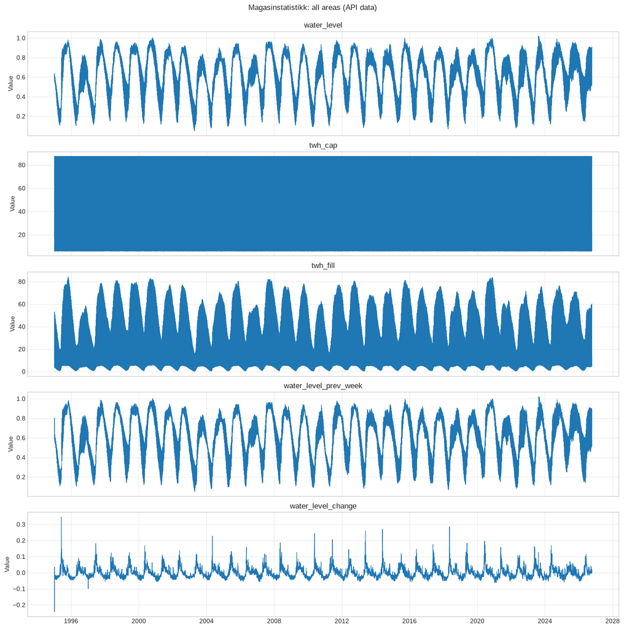

```python
# Figure 1: each measurement in its own panel, plotted against time.
# Yes this looks wrong due to overlapping area_type and area_number.
# Kept the "same" as P1.

fig, axes = plt.subplots(
    len(MEASUREMENT_COLUMNS), 1, figsize=(14, 14), sharex=True
)

for ax, column in zip(axes, MEASUREMENT_COLUMNS):
    ax.plot(df_mag["date"], df_mag[column], linewidth=0.8, label=column)
    ax.set_title(column)
    ax.set_ylabel("Value")
    ax.grid(True, alpha=0.4)

fig.suptitle("Magasinstatistikk: all areas (API data)", y=0.995)
fig.tight_layout()
plt.show()
```

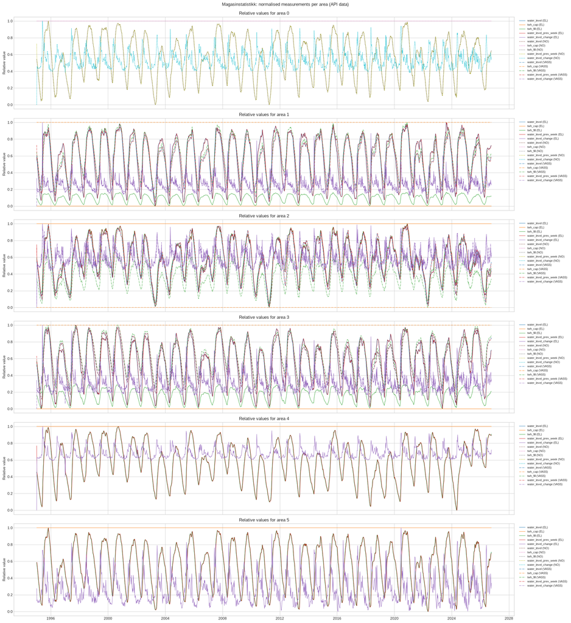

```python
# Figure 2: normalise every numeric measurement within each area number.
# Normalisation is done separately per area so that the six subplots are
# comparable even though the absolute reservoir sizes differ.

plot_df = df_mag.copy()
plot_df = plot_df.drop(columns=["iso_year", "iso_week", "next_publication_date"])

# Fetch numeric columns
numeric_cols = [
    c
    for c in plot_df.select_dtypes(include="number").columns
    if c != "area_number"
]

# Normalize values
for area_number in sorted(plot_df["area_number"].unique()):

    mask = plot_df["area_number"] == area_number

    for column in numeric_cols:

        area_values = plot_df.loc[mask, column]
        value_range = area_values.max() - area_values.min()

        if value_range == 0:
            plot_df.loc[mask, column] = 1.0
        else:
            plot_df.loc[mask, column] = (area_values - area_values.min()) / value_range

# Integer codes give a stable index into the line-style list.
area_type_codes = {
    name: code
    for code, name in enumerate(sorted(plot_df["area_type"].unique()))
}
plot_df["area_type_code"] = plot_df["area_type"].map(area_type_codes)
line_styles = ["-", "--", "-."]

fig, axes = plt.subplots(
    len(sorted(plot_df["area_number"].unique())),
    1,
    figsize=(22, 24),
    sharex=True,
)

for ax, area_number in zip(axes, sorted(plot_df["area_number"].unique())):

    area_data = plot_df[plot_df["area_number"] == area_number]
    ax.set_title(f"Relative values for area {area_number}")

    for area_type, code in area_type_codes.items():

        type_data = area_data[area_data["area_type"] == area_type]

        for column in numeric_cols:
            ax.plot(
                type_data["date"],
                type_data[column],
                label=f"{column} ({area_type})",
                linestyle=line_styles[code % len(line_styles)],
                linewidth=0.8,
            )

    ax.set_ylabel("Relative value")
    ax.legend(loc="upper left", bbox_to_anchor=(1.005, 1), fontsize=8)

fig.suptitle("Magasinstatistikk: normalised measurements per area (API data)", y=0.995)
fig.tight_layout()
plt.show()
```

## ENTSO-E cross-border transfer data

For cross-border physical flows the Norway control area is `10YNO-0--------C`.

The API is queried in both directions for each neighbour:

- `in_Domain = neighbour`, `out_Domain = NO` -> export from Norway
- `in_Domain = NO`, `out_Domain = neighbour` -> import to Norway

ENTSO-E defines `out_Domain` as the area the energy comes from and `in_Domain` as the area it flows into.  
The quantity is non-negative, so the direction is encoded in the domain order.

The parsed two-year table is cached as `data/cache/entsoe_flows.parquet`.  
Re-runs load the cache instead of repeating the HTTP requests.  
Set `REFRESH_ENTSOE = True` to fetch a new window.

```python
@dataclass(frozen=True)
class EICAreaCode:
    """A compact view of one row in the ENTSO-E EIC code list."""

    eic_code: str
    display_name: str
    name: str


def clean_text(value: Any) -> str:
    """Return a stripped string, or an empty string for missing values."""

    if pd.isna(value):
        return ""

    return str(value).strip()


def load_eic_codes(path: Path) -> list[EICAreaCode]:
    """Read the EIC CSV and return only the fields used by the notebook."""

    frame = pd.read_csv(path, sep=";", encoding="utf-8-sig")

    require_columns(
        frame,
        ("EicCode", "EicDisplayName", "EicLongName"),
        "EIC code list",
    )

    return [
        EICAreaCode(
            eic_code=clean_text(row["EicCode"]),
            display_name=clean_text(row["EicDisplayName"]),
            name=clean_text(row["EicLongName"]),
        )
        for _, row in frame.iterrows()
    ]


eic_path = REPO_ROOT / "data" / "Y_eicCodes.csv"
eic_objects = load_eic_codes(eic_path)

norwegian_areas = [e for e in eic_objects if e.eic_code.startswith("10YNO")]

country_areas = [
    e
    for e in eic_objects
    if e.eic_code.startswith("10Y") and len(e.display_name) == 2
]

NO_CODE = "10YNO-0--------C"  # Norway control area used by the A11 endpoint
NEIGHBOURS = ["SE", "FI", "NL", "GB", "DK", "DE"]

# Map display name -> EIC code and fail loudly if the CSV changes.
country_codes = {area.display_name: area.eic_code for area in country_areas}
missing_neighbours = sorted(set(NEIGHBOURS) - set(country_codes))

if missing_neighbours:
    raise ValueError(
        "Missing EIC codes for: " + ", ".join(missing_neighbours)
    )

border_codes = {country: country_codes[country] for country in NEIGHBOURS}

print(f"Loaded {len(eic_objects)} EIC records\n")

print("Norwegian areas:")
for area in norwegian_areas:
    print(f"  {area.eic_code}  {area.display_name:4s}  {area.name}")

print("\nNeighbour codes used:")
for country, code in border_codes.items():
    print(f"  {country}: {code}")
```

```
Loaded 1829 EIC records

Norwegian areas:
  10YNO-0--------C  NO    Norway
  10YNO-1--------2  NO1   Norwegian Area Elspot Area 1
  10YNO-2--------T  NO2   Norwegian Area Elspot Area 2
  10YNO-3--------J  NO3   Norwegian Area Elspot Area 3
  10YNO-4--------9  NO4   Norwegian Area Elspot Area 4

Neighbour codes used:
  SE: 10YSE-1--------K
  FI: 10YFI-1--------U
  NL: 10YNL----------L
  GB: 10YGB----------A
  DK: 10Y1001A1001A65H
  DE: 10Y1001A1001A83F
```

```python
ENTSOE_API = "https://web-api.tp.entsoe.eu/api?"

# The start/end of the requested window:
# exactly two years back from today, normalised to midnight UTC.

END_DATE = pd.Timestamp.now().normalize()
START_DATE = END_DATE - pd.DateOffset(years=2)
print(f"Requested window: {START_DATE} -> {END_DATE}")


def fetch_entsoe_roots(
    start: pd.Timestamp,
    end: pd.Timestamp,
    in_domain: str,
    out_domain: str,
) -> list[ET.Element]:
    """
    Fetch A11 data for one domain pair, splitting into <= 1-year chunks.

    The Transparency Platform limits the length of a single query, so the
    interval is walked one year at a time. A response without a
    Publication_MarketDocument (for example an Acknowledgement_MarketDocument
    saying "no matching data") is skipped and reported.
    """
    roots: list[ET.Element] = []
    cursor = start

    while cursor < end:

        chunk_end = min(cursor + pd.DateOffset(years=1), end)

        params = {
            "securityToken": entsoe_token,
            "documentType": "A11",  # Aggregated energy data report
            "in_Domain": in_domain,
            "out_Domain": out_domain,
            "periodStart": cursor.strftime("%Y%m%d%H%M"),
            "periodEnd": chunk_end.strftime("%Y%m%d%H%M"),
        }

        response = requests.get(ENTSOE_API, params=params, timeout=120)

        if response.ok and "Publication_MarketDocument" in response.text:
            roots.append(ET.fromstring(response.content))
        else:
            print(
                f"  no publication data for {in_domain} -> {out_domain} "
                f"({cursor.date()} to {chunk_end.date()}, HTTP {response.status_code})"
            )

        cursor = chunk_end

    return roots


# Resolution strings map to the duration of one observation in hours. The
# energy of a point is quantity (MW) multiplied by this value.
RESOLUTION_HOURS = {
    "PT15M": 0.25,
    "PT30M": 0.5,
    "PT60M": 1.0,
    "P1D": 24.0,
}


def parse_entsoe_roots(
    roots: list[ET.Element],
    border: str,
    direction: str,
) -> pd.DataFrame:
    """
    Flatten ENTSO-E TimeSeries/Period/Point XML into a tabular DataFrame.

    The nested structure is: TimeSeries -> Period -> Point. Position is
    1-based within the period, so the timestamp of a point is
    period_start + resolution * (position - 1).
    """
    rows: list[dict[str, Any]] = []

    for root in roots:
        for series in root.findall(".//{*}TimeSeries"):

            unit_element = series.find("{*}quantity_Measure_Unit.name")
            unit = unit_element.text if unit_element is not None else None

            for period in series.findall("{*}Period"):

                start_element = period.find("{*}timeInterval/{*}start")
                resolution_element = period.find("{*}resolution")

                if start_element is None or resolution_element is None:
                    continue

                period_start = pd.to_datetime(start_element.text)

                if period_start.tzinfo is not None:
                    period_start = (
                        period_start.tz_convert("UTC").tz_localize(None)
                    )

                resolution = resolution_element.text
                hours = RESOLUTION_HOURS.get(resolution)

                if hours is None:
                    hours = pd.Timedelta(resolution).total_seconds() / 3600.0

                for point in period.findall("{*}Point"):

                    position_element = point.find("{*}position")
                    quantity_element = point.find("{*}quantity")

                    if position_element is None or quantity_element is None:
                        continue

                    timestamp = period_start + pd.Timedelta(hours=hours) * (
                        int(position_element.text) - 1
                    )

                    rows.append(
                        {
                            "border": border,
                            "direction": direction,
                            "timestamp": timestamp,
                            "quantity": float(quantity_element.text),
                            "hours": hours,
                            "unit": unit,
                        }
                    )

    return pd.DataFrame(rows)
```

```
Requested window: 2024-10-20 00:00:00 -> 2026-10-20 00:00:00
```

```python
# ENTSO-E data are cached as a parquet file for the same reason as the NVE
# data: a normal notebook run should not depend on network access or on the
# API rate limit. Set REFRESH_ENTSOE = True (or delete the file) to fetch a
# fresh two-year window.

FLOW_COLUMNS = ("border", "direction", "timestamp", "quantity", "hours", "unit")
ENTS0E_CACHE = CACHE_DIR / "entsoe_flows.parquet"
REFRESH_ENTSOE = False


def fetch_all_entsoe(start: pd.Timestamp, end: pd.Timestamp) -> pd.DataFrame:
    """Fetch both directions for every neighbour and return one tidy table."""
    flow_frames: list[pd.DataFrame] = []

    # This is 2 requests per border per year (normally 24 HTTP calls). The loop
    # prints a short line so the notebook output documents what was retrieved.
    for border in NEIGHBOURS:
        neighbour_code = border_codes[border]

        for direction, in_code, out_code in [
            # out_Domain is the source and in_Domain is the destination.
            ("Export", neighbour_code, NO_CODE),
            ("Import", NO_CODE, neighbour_code),
        ]:
            print(f"{border} {direction}: {in_code} -> {out_code}")

            roots = fetch_entsoe_roots(start, end, in_code, out_code)
            frame = parse_entsoe_roots(roots, border, direction)

            print(f"  parsed {len(frame):,} points")
            flow_frames.append(frame)

    frame = pd.concat(flow_frames, ignore_index=True)
    require_columns(frame, FLOW_COLUMNS, "ENTS0E parsed data")

    # Different resolutions can describe the same instant. Keep the last row
    # for each key; the API returns the most detailed/newest series last.
    frame = (
        frame.drop_duplicates(["border", "direction", "timestamp"], keep="last")
        .sort_values(["border", "direction", "timestamp"])
        .reset_index(drop=True)
    )

    # The partition key in Cassandra uses the calendar year.
    frame["year"] = frame["timestamp"].dt.year
    return frame


def load_entsoe_flows() -> pd.DataFrame:
    """Load the flow table from the parquet cache or fetch and cache it."""

    if ENTS0E_CACHE.exists() and not REFRESH_ENTSOE:

        frame = pd.read_parquet(ENTS0E_CACHE)
        require_columns(frame, (*FLOW_COLUMNS, "year"), "ENTS0E cache")

        print(
            f"Loaded {len(frame):,} flow rows from cache: "
            f"{ENTS0E_CACHE.relative_to(REPO_ROOT)}"
        )

        return frame.sort_values(
            ["border", "direction", "timestamp"]
        ).reset_index(drop=True)

    frame = fetch_all_entsoe(START_DATE, END_DATE)
    frame.to_parquet(ENTS0E_CACHE, index=False)

    print(
        f"Cached {len(frame):,} flow rows in "
        f"{ENTS0E_CACHE.relative_to(REPO_ROOT)}"
    )

    return frame


df_flows = load_entsoe_flows()

print(f"\nCombined shape: {df_flows.shape}")
print(
    f"Window in data: {df_flows['timestamp'].min()} -> "
    f"{df_flows['timestamp'].max()}"
)
print(df_flows.groupby(["border", "direction"]).size().unstack(fill_value=0))
display(df_flows.head())
```

```
Loaded 253,649 flow rows from cache: data/cache/entsoe_flows.parquet

Combined shape: (253649, 7)
Window in data: 2024-10-20 00:00:00 -> 2026-10-19 23:45:00
direction  Export  Import
border
DE          47181   16732
DK          41271   18825
FI          18514    5406
GB          14852    2726
NL           9250    3524
SE          36094   39274
```

|  | border | direction | timestamp | quantity | hours | unit | year |
| --- | --- | --- | --- | --- | --- | --- | --- |
| 0 | DE | Export | 2024-10-20 00:00:00 | 904.48 | 0.25 | MAW | 2024 |
| 1 | DE | Export | 2024-10-20 00:15:00 | 902.72 | 0.25 | MAW | 2024 |
| 2 | DE | Export | 2024-10-20 00:30:00 | 902.88 | 0.25 | MAW | 2024 |
| 3 | DE | Export | 2024-10-20 00:45:00 | 901.12 | 0.25 | MAW | 2024 |
| 4 | DE | Export | 2024-10-20 01:00:00 | 894.56 | 0.25 | MAW | 2024 |

```python
# Sanity-check the parsed quantities and the yearly coverage before loading anything into Cassandra.

summary = (
    df_flows.assign(mwh=df_flows["quantity"] * df_flows["hours"])
    .groupby(["border", "direction"])
    .agg(
        points=("quantity", "size"),
        min_quantity=("quantity", "min"),
        max_quantity=("quantity", "max"),
        total_twh=("mwh", "sum"),
    )
)
# Energy = MW * hours; one TWh is 1e6 MWh.
summary["total_twh"] = summary["total_twh"] / MWH_PER_TWH
display(summary.round(3))

print("Year coverage:")
display(df_flows.groupby(["border", "year"]).size().unstack(fill_value=0))
```

| border | direction | points | min_quantity | max_quantity | total_twh |
| --- | --- | --- | --- | --- | --- |
| DE | Export | 47181 | 0.0 | 1406.560 | 11.361 |
|  | Import | 16732 | 0.0 | 1410.860 | 3.077 |
| DK | Export | 41271 | 0.0 | 1677.130 | 13.885 |
|  | Import | 18825 | 0.0 | 1612.124 | 3.982 |
| FI | Export | 18514 | 0.0 | 115.370 | 0.580 |
|  | Import | 5406 | 0.0 | 100.020 | 0.088 |
| GB | Export | 14852 | 0.0 | 1472.870 | 17.490 |
|  | Import | 2726 | 0.0 | 1397.767 | 1.828 |
| NL | Export | 9250 | 0.0 | 676.062 | 4.241 |
|  | Import | 3524 | 0.0 | 687.610 | 1.053 |
| SE | Export | 36094 | 0.0 | 3564.050 | 8.559 |
|  | Import | 39274 | 0.0 | 4353.100 | 17.325 |

```
Year coverage:
```

| year border | 2024 | 2025 | 2026 |
| --- | --- | --- | --- |
| DE | 5464 | 30813 | 27636 |
| DK | 1817 | 29025 | 29254 |
| FI | 1935 | 9052 | 12933 |
| GB | 1647 | 8695 | 7236 |
| NL | 1663 | 6720 | 4391 |
| SE | 2637 | 26035 | 46696 |

## Cassandra storage

Spark writes the DataFrame directly with the Cassandra connector.  
The table is recreated on each full notebook run so the result is reproducible.

```python
FLOW_TABLE = "entsoe_flows"
CASSANDRA_FLOW_COLUMNS = (
    "border",
    "year",
    "direction",
    "ts",
    "quantity",
    "hours",
    "unit",
)

session.execute(f"DROP TABLE IF EXISTS {FLOW_TABLE}")
session.execute(
    f"""
    CREATE TABLE {FLOW_TABLE} (
        border TEXT,
        year INT,
        direction TEXT,
        ts TIMESTAMP,
        quantity DOUBLE,
        hours DOUBLE,
        unit TEXT,
        PRIMARY KEY ((border, year), direction, ts)
    )
    """
)

# Only the columns that exist in the Cassandra schema are sent to Spark.
flow_to_write = (
    df_flows.rename(columns={"timestamp": "ts"})[list(CASSANDRA_FLOW_COLUMNS)].copy()
)

# Ensure nullable-free key columns and plain Python/NumPy types.
flow_to_write["ts"] = pd.to_datetime(flow_to_write["ts"])
flow_to_write["year"] = flow_to_write["year"].astype(int)
flow_to_write["quantity"] = flow_to_write["quantity"].astype(float)
flow_to_write["hours"] = flow_to_write["hours"].astype(float)

flow_sdf = spark.createDataFrame(flow_to_write)

(
    flow_sdf.write.format("org.apache.spark.sql.cassandra")
    .options(table=FLOW_TABLE, keyspace=KEYSPACE)
    .mode("append")
    .save()
)

# Read the table back through Spark to verify the write.
cassandra_sdf = (
    spark.read.format("org.apache.spark.sql.cassandra")
    .options(table=FLOW_TABLE, keyspace=KEYSPACE)
    .load()
)
cassandra_sdf.createOrReplaceTempView("entsoe_flows")

print(f"Rows in Cassandra (Spark count): {cassandra_sdf.count():,}")
cassandra_sdf.groupBy("border", "direction").count().orderBy("border", "direction").show()
```

```
Rows in Cassandra (Spark count): 253,649
```

```
[Stage 8:=====================================================>   (32 + 2) / 34]
```

```
+------+---------+-----+
|border|direction|count|
+------+---------+-----+
|    DE|   Export|47181|
|    DE|   Import|16732|
|    DK|   Export|41271|
|    DK|   Import|18825|
|    FI|   Export|18514|
|    FI|   Import| 5406|
|    GB|   Export|14852|
|    GB|   Import| 2726|
|    NL|   Export| 9250|
|    NL|   Import| 3524|
|    SE|   Export|36094|
|    SE|   Import|39274|
+------+---------+-----+
```

## Spark extraction and plots

The plots use Spark SQL to select only the needed columns and to aggregate energy.  
`quantity` is in MW and `hours` is the length of each observation, `SUM(quantity * hours) / 1e6` gives TWh.

- Pie chart: total export and import for one connection in one complete year.
- Line plot: January of a chosen year for one connection, with one line per direction, followed by a version showing every connection and direction.

```
SE 2025 totals (TWh):
```

|  | direction | twh |
| --- | --- | --- |
| 0 | Import | 8.076 |
| 1 | Export | 4.593 |

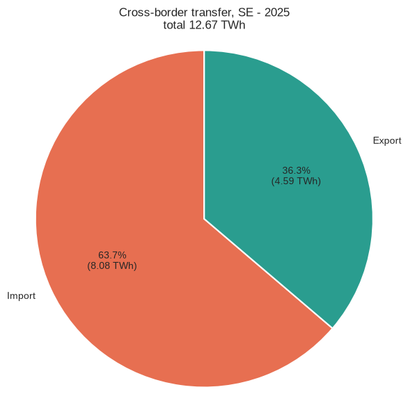

```python
# User-facing choices for the two required plots.
PIE_BORDER = "SE"
PIE_YEAR = 2025
LINE_BORDER = "SE"
LINE_YEAR = 2025
LINE_MONTH = 1

# --- Pie chart -------------------------------------------------------------
pie_sql = f"""
    SELECT direction,
           ROUND(SUM(quantity * hours) / {MWH_PER_TWH}.0, 3) AS twh
    FROM entsoe_flows
    WHERE border = '{PIE_BORDER}' AND year = {PIE_YEAR}
    GROUP BY direction
    ORDER BY direction DESC
"""

pie_df = spark.sql(pie_sql).toPandas()

print(f"{PIE_BORDER} {PIE_YEAR} totals (TWh):")
display(pie_df)

fig, ax = plt.subplots(figsize=(6, 6))
colors = {"Export": "#2a9d8f", "Import": "#e76f51"}
ax.pie(
    pie_df["twh"],
    labels=pie_df["direction"],
    autopct=lambda pct: f"{pct:.1f}%\n({pct / 100 * pie_df['twh'].sum():.2f} TWh)",
    startangle=90,
    colors=[colors.get(d, "#999999") for d in pie_df["direction"]],
    wedgeprops={"edgecolor": "white", "linewidth": 1.5},
)

ax.set_title(
    f"Cross-border transfer, {PIE_BORDER} - {PIE_YEAR}\n"
    f"total {pie_df['twh'].sum():.2f} TWh"
)

ax.axis("equal")

plt.tight_layout()
plt.show()
```

```
SE: 1,167 points in month 1/2025
```

|  | ts | direction | quantity |
| --- | --- | --- | --- |
| 0 | 2025-01-01 00:00:00 | Import | 2815.20 |
| 1 | 2025-01-01 01:00:00 | Import | 2278.94 |
| 2 | 2025-01-01 02:00:00 | Import | 2531.94 |
| 3 | 2025-01-01 03:00:00 | Import | 2690.79 |
| 4 | 2025-01-01 04:00:00 | Import | 2825.85 |

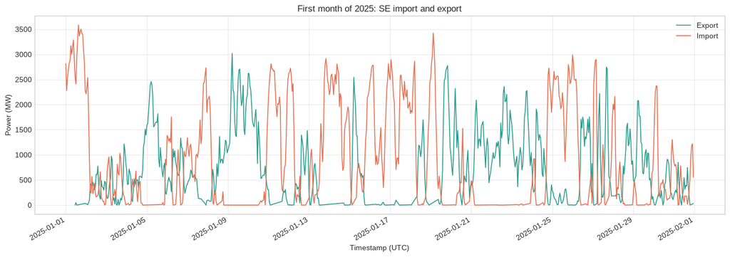

```python
# Line plot
line_sql = f"""
    SELECT ts, direction, quantity
    FROM entsoe_flows
    WHERE border = '{LINE_BORDER}'
      AND year = {LINE_YEAR}
      AND MONTH(ts) = {LINE_MONTH}
    ORDER BY ts
"""

line_df = spark.sql(line_sql).toPandas()
line_df["ts"] = pd.to_datetime(line_df["ts"])

print(f"{LINE_BORDER}: {len(line_df):,} points in month {LINE_MONTH}/{LINE_YEAR}")
display(line_df.head())

fig, ax = plt.subplots(figsize=(14, 5))

for direction, group in line_df.groupby("direction"):
    ax.plot(
        group["ts"],
        group["quantity"],
        label=direction,
        linewidth=1.2,
        color=colors.get(direction),
    )

ax.set_title(
    f"First month of {LINE_YEAR}: {LINE_BORDER} import and export"
)

ax.set_xlabel("Timestamp (UTC)")
ax.set_ylabel("Power (MW)")
ax.legend()
ax.grid(True, alpha=0.4)
fig.autofmt_xdate()

plt.tight_layout()
plt.show()
```

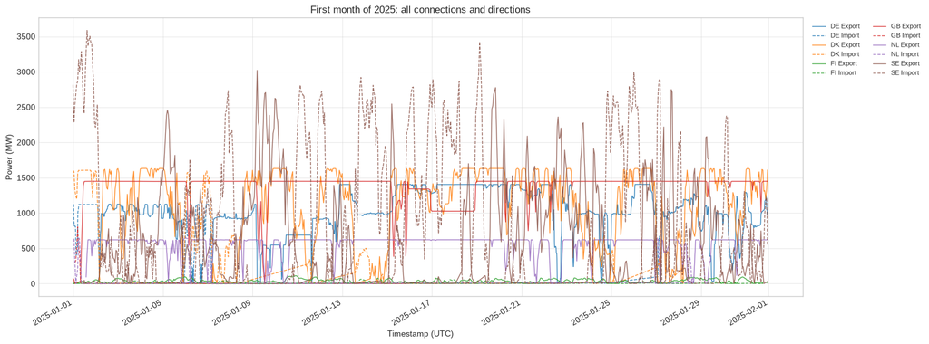

```python
# Line plot of all connections and directions
all_lines_sql = f"""
    SELECT border, direction, ts, quantity
    FROM entsoe_flows
    WHERE year = {LINE_YEAR} AND MONTH(ts) = {LINE_MONTH}
    ORDER BY ts
"""

all_lines_df = spark.sql(all_lines_sql).toPandas()
all_lines_df["ts"] = pd.to_datetime(all_lines_df["ts"])

fig, ax = plt.subplots(figsize=(16, 6))
palette = plt.get_cmap("tab10")
border_colors = {
    border: palette(i % 10) for i, border in enumerate(sorted(NEIGHBOURS))
}
linestyles = {"Export": "-", "Import": "--"}

for (border, direction), group in all_lines_df.groupby(["border", "direction"]):
    ax.plot(
        group["ts"],
        group["quantity"],
        label=f"{border} {direction}",
        color=border_colors[border],
        linestyle=linestyles.get(direction, ":"),
        linewidth=1.0,
        alpha=0.85,
    )

ax.set_title(
    f"First month of {LINE_YEAR}: all connections and directions"
)
ax.set_xlabel("Timestamp (UTC)")
ax.set_ylabel("Power (MW)")
ax.legend(ncol=2, fontsize=8, loc="upper left", bbox_to_anchor=(1.005, 1))
ax.grid(True, alpha=0.4)
fig.autofmt_xdate()
plt.tight_layout()
plt.show()
```

## MongoDB export

The same Spark-selected columns are inserted into MongoDB.  
If `SHOULD_PUSH = True`:

- The collection is dropped and rebuilt on every full run so that repeated notebook executions do not create duplicates.
- Documents are inserted in chunks to keep each request below the request limits.

```python
SHOULD_PUSH = False  # Set to True to push the flow table to MongoDB

MONGO_DB_NAME = "ind320"
MONGO_COLLECTION_NAME = "entsoe_flows"
MONGO_INSERT_CHUNK_SIZE = 5000

mongo_client = MongoClient(mongo_url, serverSelectionTimeoutMS=20000)
mongo_client.admin.command("ping")
mongo_db = mongo_client[MONGO_DB_NAME]
mongo_collection = mongo_db[MONGO_COLLECTION_NAME]

if SHOULD_PUSH:
    mongo_collection.drop()

    mongo_sql = """
        SELECT border, year, direction, ts AS timestamp, quantity, hours, unit
        FROM entsoe_flows
        ORDER BY border, year, direction, ts
    """
    mongo_pdf = spark.sql(mongo_sql).toPandas()
    mongo_pdf["timestamp"] = pd.to_datetime(mongo_pdf["timestamp"])

    records = mongo_pdf.to_dict("records")
    for start in range(0, len(records), MONGO_INSERT_CHUNK_SIZE):
        mongo_collection.insert_many(
            records[start : start + MONGO_INSERT_CHUNK_SIZE],
            ordered=False,
        )

    # Indexes match the filters used by the Streamlit page: connection + year for
    # the pie chart, and timestamp for the month line plot.
    mongo_collection.create_index([("border", 1), ("year", 1)])
    mongo_collection.create_index([("timestamp", 1)])

print(f"Documents in MongoDB: {mongo_collection.count_documents({}):,}")
print("Sample document:")
display(mongo_collection.find_one({}, {"_id": 0}))
```

```
Documents in MongoDB: 253,649
Sample document:
```

```
{'border': 'DE',
 'year': 2024,
 'direction': 'Export',
 'timestamp': datetime.datetime(2024, 10, 20, 0, 0),
 'quantity': 904.48,
 'hours': 0.25,
 'unit': 'MAW'}
```

```python
# Final cleanup. Cassandra itself is left running so the Streamlit app can use
# it; only the client connections are closed.
spark.stop()
cluster.shutdown()
mongo_client.close()
print("Spark session, Cassandra session and MongoDB client closed.")
```

```
Spark session, Cassandra session and MongoDB client closed.
```